# Homework 11

Małgorzata Pujszo

Saturday, January 02, 2016

I considered data sleepstudy from lme4 package. Firstly, let’s see what our data looks like.

```r
library(lme4)
library(lattice)
library(ggplot2)
head(sleepstudy)
```

```
##   Reaction Days Subject
## 1 249.5600    0     308
## 2 258.7047    1     308
## 3 250.8006    2     308
## 4 321.4398    3     308
## 5 356.8519    4     308
## 6 414.6901    5     308
```

```r
nrow(sleepstudy)
```

```
## [1] 180
```

```r
unique(sleepstudy$Subject)
```

```
##  [1] 308 309 310 330 331 332 333 334 335 337 349 350 351 352 369 370 371
## [18] 372
## 18 Levels: 308 309 310 330 331 332 333 334 335 337 349 350 351 352 ... 372
```

```r
length(unique(sleepstudy$Subject))
```

```
## [1] 18
```

As we can see our data is in a long format - we have information of reaction of a given patient in a given day. As a result, one patient is present in a data frame a couple times.

Now, I plotted the relation between Reaction and Days for each Subject independently.

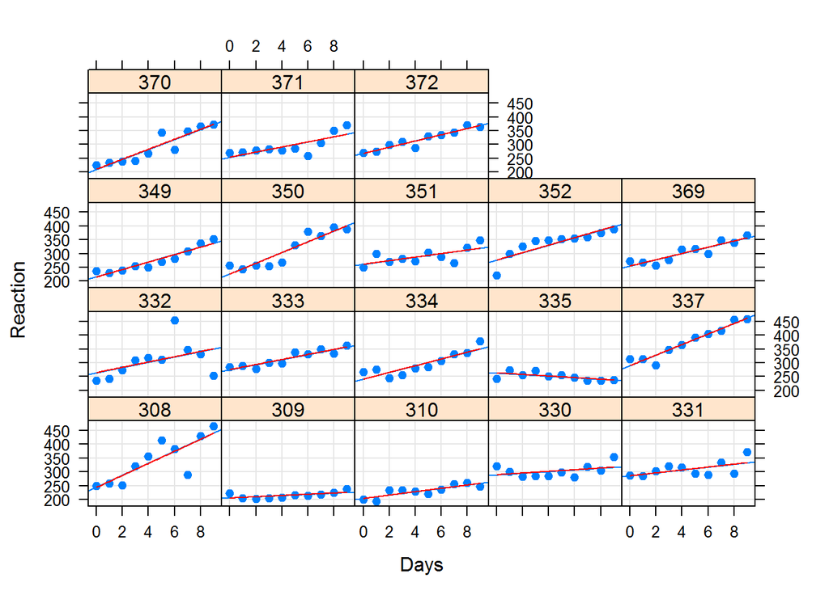

```r
panel.with.square <- function(...){
  nx = list(...)$x
  ny = list(...)$y
  cc = lm(ny~nx)$coef
  panel.xyplot(...)
  panel.curve(x*cc[2]+cc[1], from=min(nx), to=max(nx), col="red")
}

xyplot(Reaction ~ Days | Subject, sleepstudy, type = c("g","p","r"),
  xlab = "Days", ylab = "Reaction", pch=19,
  panel = panel.with.square)
```

From the plot, one can infer that slopes for each Subject are different. Building a model we should take it into account. Consequently, I modelled the relation between Reaction and Days as linear but I also added random component depending on Subject.

```r
model <- lmer(Reaction ~ Days + (Days|Subject), data=sleepstudy)
summary(model)
```

```
## Linear mixed model fit by REML ['lmerMod']
## Formula: Reaction ~ Days + (Days | Subject)
##    Data: sleepstudy
##
## REML criterion at convergence: 1743.6
##
## Scaled residuals:
##     Min      1Q  Median      3Q     Max
## -3.9536 -0.4634  0.0231  0.4634  5.1793
##
## Random effects:
##  Groups   Name        Variance Std.Dev. Corr
##  Subject  (Intercept) 612.09   24.740
##           Days         35.07    5.922   0.07
##  Residual             654.94   25.592
## Number of obs: 180, groups:  Subject, 18
##
## Fixed effects:
##             Estimate Std. Error t value
## (Intercept)  251.405      6.825   36.84
## Days          10.467      1.546    6.77
##
## Correlation of Fixed Effects:
##      (Intr)
## Days -0.138
```

In the model, I allowed occurence of dependence of random effects. Let’s test whether this assumption of dependence is significant.

```r
model1 <- lmer(Reaction ~ Days + (Days-1|Subject) + (1|Subject), data=sleepstudy)
summary(model1)
```

```
## Linear mixed model fit by REML ['lmerMod']
## Formula: Reaction ~ Days + (Days - 1 | Subject) + (1 | Subject)
##    Data: sleepstudy
##
## REML criterion at convergence: 1743.7
##
## Scaled residuals:
##     Min      1Q  Median      3Q     Max
## -3.9626 -0.4625  0.0204  0.4653  5.1860
##
## Random effects:
##  Groups    Name        Variance Std.Dev.
##  Subject   Days         35.86    5.988
##  Subject.1 (Intercept) 627.57   25.051
##  Residual              653.58   25.565
## Number of obs: 180, groups:  Subject, 18
##
## Fixed effects:
##             Estimate Std. Error t value
## (Intercept)  251.405      6.885   36.51
## Days          10.467      1.560    6.71
##
## Correlation of Fixed Effects:
##      (Intr)
## Days -0.184
```

```r
anova(model, model1)
```

```
## refitting model(s) with ML (instead of REML)
```

```
## Data: sleepstudy
## Models:
## model1: Reaction ~ Days + (Days - 1 | Subject) + (1 | Subject)
## model: Reaction ~ Days + (Days | Subject)
##        Df    AIC    BIC  logLik deviance  Chisq Chi Df Pr(>Chisq)
## model1  5 1762.0 1778.0 -876.00   1752.0
## model   6 1763.9 1783.1 -875.97   1751.9 0.0639      1     0.8004
```

Since the p-value is high, we don’t need to assume dependence of random effects. In further analysis I used model1.

The last thing I did was extracting slopes for different patients (there are in vector “slopes”) and presenting summary statistics.

```r
slopes <- ranef(model1)$Subject[,1] + fixef(model1)[2]
summary(slopes)
```

```
##    Min. 1st Qu.  Median    Mean 3rd Qu.    Max.
## -0.4387  7.3030 10.7600 10.4700 13.4200 19.7900
```